# boulder

### What kind of damage did the 2013 floods cause in Boulder?

#### By Eric Foster-Moore

There was a lot of flooding in Boulder in 2013. Boulder Creek experienced the biggest floods since the Boulder Creek gauge at North 75th Street started recording river levels in 1987. I wanted to find out what kind of damage these floods caused and whether there was an unptick in construction permits following the floods. Turns out there was. I was surprised to learn, however, that the uptick was not caused by an increase in permits related to flooding or repairs but to roofing. The main result of my work is the figure below. If you read on past that, you'll see how I created it and a bunch of other cool figures that I made too.

So, one hypothesis to come out of this quick analysis is that the majority of the damage caused by the 2013 flood events was actually caused by precipitation. Or, perhaps, people quickly discovered that their roofs were not as waterproof as they thought.

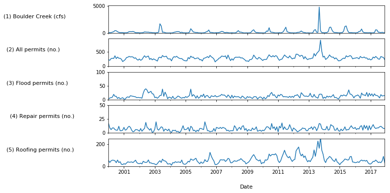

```python
figure1
```

### The rest of this document

In the remainder of this document, you can see exactly how I created the figure above, which involved pulling the streamflow data from the Boulder Creek gauge at North 75th Street and the construction permit data from Boulder's open data portal. I clean these datasets, do some exploratory analyses, and then plot them as separate axes in the figure you see above.

I also look at the location of residential versus non-residential construction permits and at whether the lag time between permit application and permit approval is going up or down.

```python
# Creator:       Eric Foster-Moore
# Created:       January 6, 2018
# Last edited:   January 8, 2018

import numpy as np
import pandas as pd
from matplotlib import pyplot as plt
import os
from geopandas import GeoDataFrame
import shapely
import json
import geopandas as gpd
import sys
from shapely.geometry import Point

RAWDATA_DIR = os.path.join('..', 'boulder', 'rawdata')
OUTPUT_DIR = os.path.join('..', 'boulder', 'outputs')
SCRATCH_DIR = os.path.join('..', 'boulder', 'scratch')
SPATIAL_RAW_DIR = os.path.join('..', 'boulder', 'rawdata')

%matplotlib inline
```

#### Streamflow data

I start by looking at the streamflow data from the Boulder Creek at North 75th Street gauge, which I obtained from https://waterdata.usgs.gov/nwis/dv?format=rdb&site_no=06730200&referred_module=sw&period=&begin_date=1986-01-01&end_date=2018-01-06

```python
# Read in data from the Boulder Creek stream gauge

streamflow = pd.read_csv(os.path.join(RAWDATA_DIR, 'boulder_creek_gauge.csv'))
```

```python
# Convert date to datetime

streamflow['timestamp'] = pd.to_datetime(streamflow['datetime'])
```

### 2013 Floods

In the figure below, I plot the discharge of Boulder Creek at North 75th Street for the entire period of record. The 2013 floods were the biggest Boulder Creek experienced since 1987. In the lower panel, I zoom in on 2013. We can see that the floods occurred in early September. Between September 11 and September 12, Boulder Creek's discharged went from 349 cfs to 4,770 cfs.

```
Text(0.5,0,'Date')
```

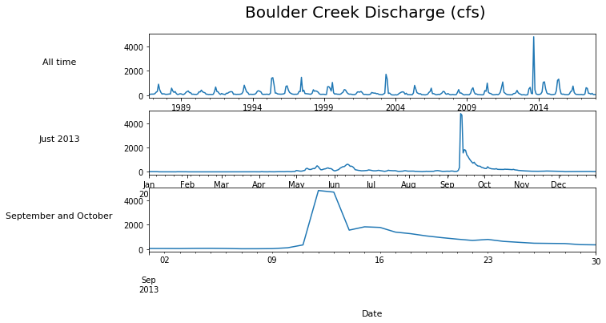

```python
fig, (ax1, ax2, ax3) = plt.subplots(nrows=3, ncols=1, sharex=False, sharey=False, figsize=(10,5))

streamflow.groupby(pd.Grouper(key='timestamp', freq='M')).gauge_height.max().plot(ax=ax1)
streamflow[streamflow['timestamp'].dt.year == 2013].groupby(pd.Grouper(key='timestamp', freq='D')).gauge_height.max().plot(ax=ax2)
streamflow[(streamflow['timestamp'] >= '2013-09-01') & (streamflow['timestamp'] <= '2013-09-30')].groupby(pd.Grouper(key='timestamp', freq='D')).gauge_height.max().plot(ax=ax3)

ylabelrotation = 'horizontal'
ylabelpad = 80

ax1.set_ylabel('All time', rotation=ylabelrotation, labelpad=ylabelpad, fontsize=11)
ax2.set_ylabel('Just 2013', rotation=ylabelrotation, labelpad=ylabelpad, fontsize=11)
ax3.set_ylabel('September and October', rotation=ylabelrotation, labelpad=ylabelpad, fontsize=11)


fig.suptitle('Boulder Creek Discharge (cfs)', fontsize=20)

plt.xlabel('Date', labelpad=20, fontsize=11)
```

### Permit data

Now I load up the construction permit data, clean it, and make some figures

```python
# Read in raw permit data

permits = pd.read_csv(os.path.join(RAWDATA_DIR, 'all_construction_permits.csv'))
original_length = len(permits)
print('Original permit df length: ', original_length)
```

```
Original permit df length:  107103
```

```python
# Convert construction permit date strings to Pandas dates

permits['APPROVED'] = pd.to_datetime(permits['APPROVED'], format='%m/%d/%Y') # http://strftime.org/ <-- useful reference
permits['APPLIED'] = pd.to_datetime(permits['APPLIED'], format='%m/%d/%Y')

# Create year-only column

permits['year_approved'] = permits['APPROVED'].dt.year
permits['year_applied'] = permits['APPLIED'].dt.year

# Examine number of permits applied for per year

print(permits.year_applied.value_counts(sort=False, dropna=False))
print(permits['year_applied'].isnull().sum())
```

```
1999      13
2000    5035
2001    5603
2002    5542
2003    5599
2004    5403
2005    5364
2006    5681
2007    5984
2008    5820
2009    5570
2010    6301
2011    5927
2012    6529
2013    7785
2014    6140
2015    6189
2016    6338
2017    6280
Name: year_applied, dtype: int64
0
```

```python
# Disregard permits applied for or approved in 1999 (incomplete year or data entry error)

permits = permits[permits.year_applied != 1999]
permits = permits[permits.year_approved != 1999]
minus1999 = len(permits)

print('Original length: ', original_length)
print('Length after dropping 1999: ', minus1999)
print('Dropped: ', original_length-minus1999)

# Drop any permits without a year applied date (there are none in fact)

permits.dropna(subset=['year_applied'], inplace=True)
minus_na = len(permits)
print('Nan dropped: ', minus1999-minus_na)
```

```
Original length:  107103
Length after dropping 1999:  107069
Dropped:  34
Nan dropped:  0
```

### Permits per year

Here is our first indication of the spike in construction permits in 2013

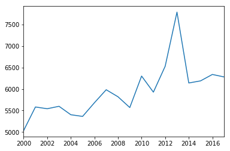

```python
# Plot number of permits applied for each year

permits_per_year = permits.APPLIED.dt.year.value_counts(sort=False)
permits_per_year.plot()
```

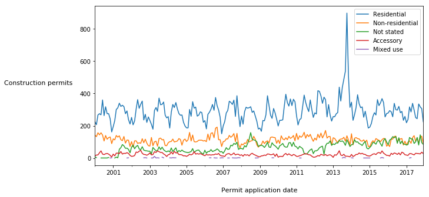

```python
category_to_label = {

    'Residential': 'Residential',
    'NonResidential': 'Non-residential',
    'Not Stated': 'Not stated',
    'Accessory': 'Accessory',
    'Mixed Use': 'Mixed use'
}

fig, ax = plt.subplots(figsize=(10,5))

hold = permits['CATEGORY'].value_counts().iloc[:5]
for idx, val in zip(hold.index, hold.values):
    tmp = permits[(permits['CATEGORY'] == idx)]
    x = tmp.groupby('APPLIED').size().resample('M').sum()
    x.plot(label=category_to_label[idx], ax=ax)

ax.set_ylabel('Construction permits', rotation='horizontal', labelpad=70, fontsize=11)
plt.xlabel('Permit application date', labelpad=20, fontsize=11)
plt.legend()
```

```python
permits['repair'] = permits['BUILING USES AND WORK SCOPES'].str.contains('Repair|repair')
permits['illegal'] = permits['NARRATIVE DESCRIPTION'].str.contains('without permit')
permits['flood'] = permits['PERMIT TYPES'].str.contains('Flood|flood')
permits['roofing'] = permits['PERMIT TYPES'].str.contains('Roofing|roofing')
permits['mechanical'] = permits['PERMIT TYPES'].str.contains('Mechanical|mechanical')
```

```python
print('Repair permits: ', permits.repair.value_counts())
print('Illegal work: ', permits.illegal.value_counts())
print('Flood permits: ', permits.flood.value_counts())
print('Roofing permits: ', permits.roofing.value_counts())
print('Mechanical permits: ', permits.mechanical.value_counts())
```

```
Repair permits:  False    105452
True       1616
Name: repair, dtype: int64
Illegal work:  False    106988
True         16
Name: illegal, dtype: int64
Flood permits:  False    104372
True       2697
Name: flood, dtype: int64
Roofing permits:  False    95016
True     12053
Name: roofing, dtype: int64
Mechanical permits:  False    72511
True     34558
Name: mechanical, dtype: int64
```

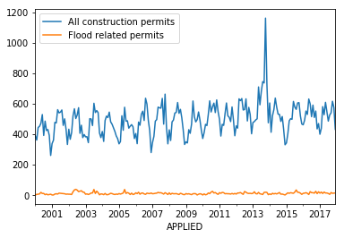

```python
permits.groupby(pd.Grouper(key='APPLIED', freq='M')).size().plot(label='All construction permits')
permits[permits['flood'] == True].groupby(pd.Grouper(key='APPLIED', freq='M')).size().plot(label='Flood related permits')
plt.legend()
```

```python
# Let's see what the most common permit types were in 2013 (maybe should have started here)

permits[permits['APPLIED'].dt.year == 2013]['PERMIT TYPES'].value_counts().nlargest(10)
```

```
Mechanical                                    1609
Roofing                                       1457
Right-of-Way                                   653
Electrical                                     487
Fire                                           452
Building, Electrical, Mechanical, Plumbing     447
Building                                       272
Fence                                          259
Electrical, Mechanical                         247
Wastewater                                     176
Name: PERMIT TYPES, dtype: int64
```

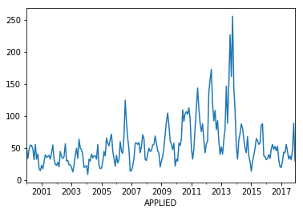

```python
# Plot the number of roofing permits over time

permits[permits['roofing'] == True].groupby(pd.Grouper(key='APPLIED', freq='M')).size().plot(label='Roofing related permits')
```

```python
repair_permits = permits[permits['repair'] == True]
flood_permits = permits[permits['flood'] == True]
```

```
Text(0.5,0,'Date')
```

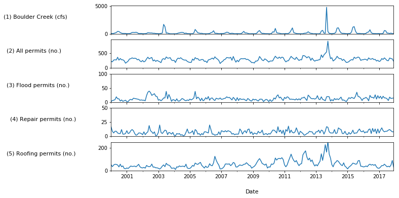

```python
# Putting it all together

figure1, (ax1, ax2, ax3, ax4, ax5) = plt.subplots(nrows=5, ncols=1, sharex=True, sharey=False, figsize=(10,6))

ylabelpad = 180
ylabelrotation='horizontal'
alignment='left'

ax1.set_ylabel('(1) Boulder Creek (cfs)', rotation=ylabelrotation, labelpad=ylabelpad, fontsize=11, horizontalalignment=alignment)
ax1.set_ylim([0, 5100])

ax2.set_ylabel('(2) All permits (no.)', rotation=ylabelrotation, labelpad=ylabelpad, fontsize=11, horizontalalignment=alignment)
ax2.set_ylim([0, 950])

ax3.set_ylabel('(3) Flood permits (no.)', rotation=ylabelrotation, labelpad=ylabelpad, fontsize=11, horizontalalignment=alignment)
ax3.set_ylim([0, 100])

ax4.set_ylabel('(4) Repair permits (no.)', rotation=ylabelrotation, labelpad=ylabelpad, fontsize=11, horizontalalignment=alignment)
ax4.set_ylim([0, 50])

ax5.set_ylabel('(5) Roofing permits (no.)', rotation=ylabelrotation, labelpad=ylabelpad, fontsize=11, horizontalalignment=alignment)
ax5.set_ylim([0, 250])


streamflow[streamflow['timestamp'].dt.year >= 2000].groupby(pd.Grouper(key='timestamp', freq='M')).gauge_height.max().plot(ax=ax1, label='Boulder Creek')
permits[permits['CATEGORY'] == 'Residential'].groupby(pd.Grouper(key='APPLIED', freq='M')).size().plot(ax=ax2, label='All residential permits')
permits[permits['flood'] == True].groupby(pd.Grouper(key='APPLIED', freq='M')).size().plot(ax=ax3, label='Flood related permits')
permits[permits['repair'] == True].groupby(pd.Grouper(key='APPLIED', freq='M')).size().plot(ax=ax4, label='Repair related permits')
permits[permits['roofing'] == True].groupby(pd.Grouper(key='APPLIED', freq='M')).size().plot(ax=ax5, label='Roofing related permits')

plt.xlabel('Date', labelpad=20, fontsize=11)
```

### Georeferencing the permit data

The permit data has addresses but not latitude/longitude coordinates. The `address` data file on Boulder's open data site, however, has coordinate pairs for city addresses. I join these addresses with coordinates to the construction permit data so that I can do spatial operations and make maps.

```python
# Load up the address point data

fields = ['ADDRESS', 'CITY', 'STATE', 'ZIPCODE', 'LONGITUDE', 'LATITUDE']
addresses = pd.read_csv('rawdata/Boulder_addresses.csv', usecols=fields, low_memory=False) # Not using 'os.path.join' bc it apparently doesn't like 'usecols' argument. Hm.
print('Missing addresses: ', addresses.ADDRESS.isnull().sum())
print('Missing city: ', addresses.CITY.isnull().sum())
```

```
Missing addresses:  0
Missing city:  0
```

```python
# Check whether there are any duplicated addresses since we want a 1:1 match on the ADDRESS COLUMN

print('Length addresses ', len(addresses))
print('Unique ADDRESS values: ', addresses.ADDRESS.nunique())
print('Unique on address, city, state, zip: ', len(addresses.groupby(['ADDRESS', 'CITY', 'STATE', 'ZIPCODE'])))
```

```
Length addresses  53605
Unique ADDRESS values:  52726
Unique on address, city, state, zip:  52793
```

```python
addresses = addresses.drop_duplicates(['ADDRESS'])
#addresses = addresses.drop_duplicates(['ADDRESS', 'CITY', 'STATE', 'ZIPCODE'])

# Note
'''
There are duplicates on ADDRESS alone, but they might have different city, state, or zip values.
Need to revisit this aspect since by dropping duplicates on ADDRESS alone I am excluding some
potentially valid rows; however, I don't have time to figure out exactly why my left join is returing
more values after dropping on unique combinations of the four columns noted above.
'''

len(addresses)
```

```
52726
```

```python
# Join the permit data to the address data to get lat/long for each permit

permits = pd.merge(permits, addresses, on='ADDRESS', how='left')
print('Length after join: ', len(permits))
print('This gives the correct length')
```

```
Length after join:  107069
This gives the correct length
```

```python
# Check for erroneous geometry

print('Describe permit LONG: ', permits.LONGITUDE.describe()) # Checking no values out of range
print()
print('Missing longitude: ', permits.LONGITUDE.isnull().sum())
print('Missing latitude: ', permits.LATITUDE.isnull().sum())
print()
print('Describe permit LAT: ', permits.LATITUDE.describe()) # Checking no values out of range
```

```
Describe permit LONG:  count    66372.000000
mean      -105.259241
std          0.022724
min       -105.325344
25%       -105.277953
50%       -105.261034
75%       -105.245654
max       -105.159757
Name: LONGITUDE, dtype: float64

Missing longitude:  40697
Missing latitude:  40697

Describe permit LAT:  count    66372.000000
mean        40.015951
std          0.024320
min         39.964862
25%         39.999796
50%         40.017430
75%         40.030518
max         40.094401
Name: LATITUDE, dtype: float64
```

```python
# So obviously a bunch of permits didn't match to address records and thus don't have lat/long values
# Let's drop these for the moment
# I do this by making a new dataframe that is the opposite of permit records that do not have longitude points

permits_missing_xy = permits.LONGITUDE.isnull().sum()
print('Total permit addresses: ', minus_na)
print('Permit addresses that did not match to a geocoded address: ', permits_missing_xy)
print('Percent of permit addresses missing xy: ', permits_missing_xy/minus_na)
print('Length of permits now: ', len(permits))

permits_xy = permits[~permits['LONGITUDE'].isnull()]
print('Length of permits excluding missing lat/long: ', len(permits_xy))
```

```
Total permit addresses:  107069
Permit addresses that did not match to a geocoded address:  40697
Percent of permit addresses missing xy:  0.380100682737
Length of permits now:  107069
Length of permits excluding missing lat/long:  66372
```

```python
# Get Boulder city geodata

# First strategy: wget

import wget

'''
Load up Boulder city limits as a geodataframe

city_limits_url = 'http://www-static.bouldercolorado.gov/docs/opendata/BoulderCityLimits.GeoJSON?_ga=2.13299511.1407779936.1515254811-2059223036.1515254811'
wget.download(city_limits_url, os.path.join(RAWDATA_DIR))

Note: Boulder website returns a '403 Forbidden' error when using the wget method.
Presumably the site is blocking me. There are other libraries I could use if I have time later. See, e.g.: https://stackoverflow.com/questions/34692009/download-image-from-url-using-python-urllib-but-receiving-http-error-403-forbid/34702897
In the interim, I'm just manually downloading the relevant spatial data files, which is quicker but less elegant
'''

# Second strategy: manual download

city_limits = gpd.read_file(os.path.join(RAWDATA_DIR, 'BoulderCityLimits.GeoJSON'))
streets = gpd.read_file(os.path.join(RAWDATA_DIR, 'Streets.GeoJSON'))
```

```python
unique_permits = permits['CASE NUMBER'].nunique()
print('Unique permit numbers: ', unique_permits)
print('Permit df length: ', len(permits))

if minus_na > unique_permits:
    print('More rows than unique permits')

if unique_permits == minus_na:
    print('All rows are unique permits')

print('Length of permits: ', len(permits))
print('Unique permit addresses: ', permits.ADDRESS.nunique())

print('Length of addresses: ', len(addresses))
print('Unique addresses: ', addresses.ADDRESS.nunique())

print(permits.CATEGORY.value_counts())

# permits['PERMIT TYPES'].value_counts() # There are a lot of permit types
print('Unique permit types: ', permits['PERMIT TYPES'].nunique())
```

```
Unique permit numbers:  107069
Permit df length:  107069
All rows are unique permits
Length of permits:  107069
Unique permit addresses:  30532
Length of addresses:  52726
Unique addresses:  52726
Residential       62880
NonResidential    24618
Not Stated        14504
Accessory          4908
Mixed Use           159
Name: CATEGORY, dtype: int64
Unique permit types:  493
```

```python
# Write clean CSV with lat/long etc for Arc

permits_xy.to_csv(os.path.join(SCRATCH_DIR, 'permits_for_arc.csv'))
len(permits_xy)
```

```
66372
```

```python
# Turn the permit data into a geodataframe

geometry = [Point(xy) for xy in zip(permits.LONGITUDE, permits.LATITUDE)]
permits_gdf = permits.drop(['LONGITUDE', 'LATITUDE'], axis=1)
crs = {'init': 'epsg:4326'}
permits_gdf = GeoDataFrame(permits_gdf, crs=crs, geometry=geometry)
```

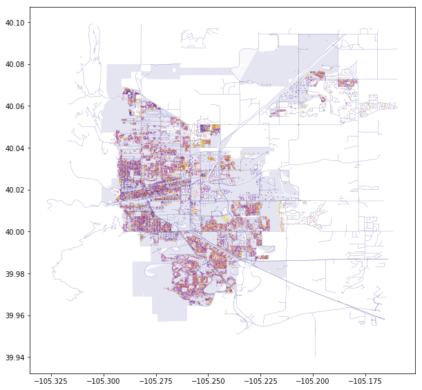

```python
# Plot construction permits and color the points by year

fig, ax1 = plt.subplots(nrows=1, ncols=1, figsize=(10,10))
city_limits.plot(ax=ax1, alpha=0.1, edgecolor='white', facecolor='navy', linewidth=0.1)
ax1.set_aspect('equal')

streets.plot(ax=ax1, alpha=0.8, edgecolor='navy', facecolor='white', linewidth=0.2)
ax1.set_aspect('equal')

permits_gdf.drop_duplicates('ADDRESS').plot(ax=ax1, alpha=0.8, markersize=0.1, c='year', cmap='plasma', scheme='quartiles')
```

Turns out there are a LOT of construction permits. They all stack on top of each other so it's hard to see whether there are patterns in where construction is happening over time. This could be interesting to explore further--i.e. are certain places becoming new construction centers but is beyond what I can explore at the moment.

```python
flood_permits = flood_permits.dropna(subset=['LONGITUDE'])
```

```python
# Turn flood permit data into GDF

geometry = [Point(xy) for xy in zip(flood_permits.LONGITUDE, flood_permits.LATITUDE)]
flood_permits_gdf = flood_permits.drop(['LONGITUDE', 'LATITUDE'], axis=1)
crs = {'init': 'epsg:4326'}
flood_permits_gdf = GeoDataFrame(flood_permits_gdf, crs=crs, geometry=geometry)
```

```python
# Read in the flood plain data

flood_2013 = gpd.read_file(os.path.join(RAWDATA_DIR, 'Flood2013Extents.GeoJSON'))
floodplain = gpd.read_file(os.path.join(RAWDATA_DIR, 'CityFloodplain.GeoJSON'))

flood100 = floodplain[floodplain['ZONEDESC'] == '100 Year']
flood500 = floodplain[floodplain['ZONEDESC'] == '500 Year']
```

### Flood-related permits for work outside the floodplain

As a side note, it looks like some people are getting flood-related construction permits for work outside the floodplain. This may be worth investigating further.

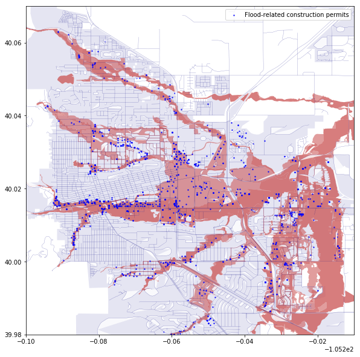

```python
# Flood permits

fig, ax1 = plt.subplots(nrows=1, ncols=1, figsize=(10,10))
city_limits.plot(ax=ax1, alpha=0.1, edgecolor='white', facecolor='navy', linewidth=0.1)
ax1.set_aspect('equal')

streets.plot(ax=ax1, alpha=0.8, edgecolor='navy', facecolor='white', linewidth=0.2)
ax1.set_aspect('equal')

flood500.plot(ax=ax1, alpha=0.6, edgecolor='none', facecolor='indianred', label='500 year flood plain')
flood100.plot(ax=ax1, alpha=0.8, edgecolor='none', facecolor='indianred', label='100 year flood plain')

#flood_2013.plot(ax=ax1, alpha=0.5, edgecolor='none', facecolor='darkred')

flood_permits_gdf.plot(ax=ax1, alpha=0.8, markersize=2.0, color='blue', label='Flood-related construction permits')

plt.xlim([ -105.3, -105.21])
plt.ylim([39.98, 40.07])
plt.legend()
```

### Which flood permits are outside the floodplain?

```python
# Double check the geometries are the same

print('Floodplain CRS: ', floodplain.crs)
print('Flood permit CFS: ', flood_permits_gdf.crs)
```

```
Floodplain CRS:  {'init': 'epsg:4326'}
Flood permit CFS:  {'init': 'epsg:4326'}
```

```python
# I ended up just doing a spatial join to check which points fall inside the floodplain polygon

permits_with_fp = gpd.sjoin(flood_permits_gdf, floodplain, how='left')
permits_with_fp.ZONEDESC.value_counts(dropna=False)
```

```
100 Year    663
NaN         463
500 Year    352
Name: ZONEDESC, dtype: int64
```

```python
# This gets you the permits that are not inside the floodplain

permits_outside_fp = permits_with_fp[permits_in_fp['ZONEDESC'].isnull()]
```

```python
permits_outside_fp[['ADDRESS', 'BUILING USES AND WORK SCOPES', 'TOTAL PROJECT VALUE']].sort_values(by=['TOTAL PROJECT VALUE'], ascending=False)
```

|  | ADDRESS | BUILING USES AND WORK SCOPES | TOTAL PROJECT VALUE |
| --- | --- | --- | --- |
| 100925 | 290 MANHATTAN DR | Schools/Educational | 6957605 |
| 16772 | 902 PEARL ST | Commercial/Retail, Core and Shell, Multifamily... | 6062208 |
| 10504 | 1801 13TH ST | Parking Garage, Core and Shell | 2800000 |
| 34283 | 1600 COMMERCE ST | Office - Technical, Tenant Remodel | 2500000 |
| 74428 | 1600 COMMERCE ST | Research & Development, Tenant Finish | 2400000 |
| 1924 | 3375 MITCHELL LN | Office - Technical, Addition and Remodel | 1800000 |
| 73862 | 2617 BROADWAY | Office - Professional, New | 1300000 |
| 19991 | 4575 14TH ST | Multifamily Dwellings, New | 1202703 |
| 12614 | 1301 CANYON BLVD | Commercial/Retail, Tenant Finish | 1200000 |
| 79564 | 4827 THUNDERBIRD DR | Multifamily Dwellings, Repair | 1149785 |
| 31138 | 2910 BLUFF ST | Multifamily Dwellings, New | 1076631 |
| 98595 | 1855 S 57TH CT | Office - Technical, Addition and Remodel | 900000 |
| 100151 | 1801 13TH ST | Office - Professional, Tenant Remodel | 879500 |
| 31140 | 2920 BLUFF ST | Multifamily Dwellings, New | 867160 |
| 26370 | 3755 SPRING VALLEY RD | Single Family Detached Dwelling, New, Garage -... | 818334 |
| 31141 | 2930 BLUFF ST | Multifamily Dwellings, New | 692319 |
| 47914 | 2525 13TH ST | Medical and Dental Clinics, Tenant Remodel | 690289 |
| 89715 | 1800 BROADWAY | Office - Professional, Remodel | 600000 |
| 58490 | 5880 BUTTE MILL RD | Service Station/Vehicular Repair, New | 550000 |
| 20046 | 1801 13TH ST | Office - Professional, Tenant Finish | 500000 |
| 46726 | 2525 13TH ST | Government Uses, Tenant Remodel | 500000 |
| 77084 | 1801 13TH ST | Office - Professional, Tenant Remodel | 497000 |
| 72416 | 2850 BASELINE RD | Restaurant, Tenant Finish | 450000 |
| 51258 | 2075 BALSAM DR | Single Family Detached Dwelling, New | 438634 |
| 74824 | 1101 WALNUT ST | Restaurant, Tenant Remodel | 424894 |
| 39769 | 2555 55TH ST | Office - Technical, Tenant Remodel | 375000 |
| 13433 | 1735 RANGE ST | Office - Professional, Alteration | 360000 |
| 59711 | 2855 VALMONT RD | Medical and Dental Clinics, Addition and Remodel | 350000 |
| 27351 | 5335 STERLING DR | Office - Technical, Tenant Finish | 350000 |
| 20161 | 3268 SENTINEL DR | Single Family Attached Dwelling, Addition and ... | 301139 |
| ... | ... | ... | ... |
| 21764 | 1880 55TH ST | Service Industrial, Existing | 0 |
| 20872 | 1801 13TH ST | Office - Professional, Existing | 0 |
| 20842 | 902 PEARL ST | Not Stated | 0 |
| 20613 | 2935 55TH ST | Government Uses, Existing | 0 |
| 20609 | 1801 13TH ST | Office - Professional, Existing | 0 |
| 20493 | 2543 BROADWAY | Restaurant, Existing | 0 |
| 20427 | 971 6TH ST | Single Family Detached Dwelling, Existing | 0 |
| 20334 | 1800 BROADWAY | Commercial/Retail, Existing | 0 |
| 19095 | 902 PEARL ST | Not Stated | 0 |
| 19094 | 902 PEARL ST | Not Stated | 0 |
| 25591 | 4778 FRANKLIN DR | Not Stated | 0 |
| 27182 | 601 S BROADWAY | Commercial/Retail, Existing | 0 |
| 34411 | 2910 BLUFF ST | Not Stated | 0 |
| 27184 | 600 S BROADWAY | Commercial/Retail, Existing | 0 |
| 34117 | 5865 ARAPAHOE RD | Existing | 0 |
| 33154 | 4580 BROADWAY | Not Stated | 0 |
| 32742 | 820 PEARL ST | Not Stated | 0 |
| 31033 | 601 S BROADWAY | Commercial/Retail, Existing | 0 |
| 31028 | 5865 ARAPAHOE RD | Not Stated | 0 |
| 30530 | 3325 28TH ST | Restaurant, Existing | 0 |
| 30529 | 3325 28TH ST | Personal Service, Existing | 0 |
| 29995 | 2511 31ST ST | Office - Professional, Existing | 0 |
| 28813 | 3763 SPRING VALLEY RD | Single Family Detached Dwelling, Existing | 0 |
| 28753 | 395 S BROADWAY | Not Stated | 0 |
| 28526 | 3375 16TH ST | Single Family Detached Dwelling, Existing | 0 |
| 28409 | 285 BROOK PL | Not Stated | 0 |
| 27995 | 4740 VALMONT RD | Commercial/Retail, Existing | 0 |
| 27577 | 704 39TH ST | Single Family Detached Dwelling, Existing | 0 |
| 27490 | 1155 MARINE ST | Multifamily Dwellings, Existing | 0 |
| 42107 | 1353 WILDWOOD CT | Single Family Detached Dwelling, Existing | 0 |

463 rows × 3 columns

### Other things I tried:

> `inside_fp = flood_permits_gdf.within(floodplain)`

The `within` method just returns a list of false values. Bet this could be made to work though.

> `inside_fp = gpd.overlay(flood_permits_gdf, floodplain, how='difference')`

The `overlay` method apparently only works with sets of polygons, not points, although I suspect that when you do a `Select by location` operation in Arc, it is actually doing a spatial join in the background.

### Permit application lag time

```python
permits['lag'] = permits['APPROVED'] - permits['APPLIED']
```

```python
permits.lag.describe()
```

```
count                     103222
mean      8 days 06:02:57.032028
std      36 days 22:06:22.949314
min         -1895 days +00:00:00
25%              0 days 00:00:00
50%              0 days 00:00:00
75%              2 days 00:00:00
max           3071 days 00:00:00
Name: lag, dtype: object
```

```python
permits.lag.isnull().sum()
```

```
3847
```

```python
permit_lag = permits.dropna(subset=['lag'])
```

```python
len(permit_lag)
```

```
103222
```

```python
permit_lag['lag'] = permit_lag.lag.astype('timedelta64[D]').astype(int)
```

```python
# Disregarding cases where lag time is a negative number

permit_lag = permit_lag[(permit_lag['lag'] >= 0)]
```

```
Text(0.5,0.98,'Lag time in applications')
```

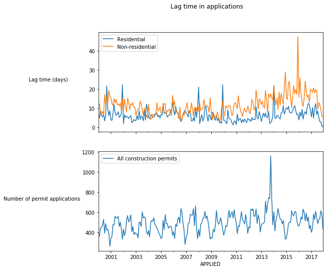

```python
fig, (ax1, ax2) = plt.subplots(sharex=True, nrows=2, ncols=1, figsize=(8,8))

permit_lag[(permit_lag['lag'] <= 500) & (permit_lag['CATEGORY'] == 'Residential')].groupby(pd.Grouper(key='APPLIED', freq='M')).lag.mean().plot(label='Residential', ax=ax1)
ax1.legend()
ax1.set_ylabel('Lag time (days)', rotation='horizontal', labelpad=80)
permit_lag[(permit_lag['lag'] <= 500) & (permit_lag['CATEGORY'] == 'NonResidential')].groupby(pd.Grouper(key='APPLIED', freq='M')).lag.mean().plot(label='Non-residential', ax=ax1)
ax1.legend()
permits.groupby(pd.Grouper(key='APPLIED', freq='M')).size().plot(label='All construction permits', ax=ax2)
ax2.set_ylabel('Number of permit applications', rotation='horizontal', labelpad=80)
ax2.legend()
plt.legend()

fig.suptitle('Lag time in applications')
```

```python
# library & dataset
import seaborn as sns
df = sns.load_dataset('iris')
```

```python
permits.CATEGORY.value_counts()
```

```
Residential       62880
NonResidential    24618
Not Stated        14504
Accessory          4908
Mixed Use           159
Name: CATEGORY, dtype: int64
```

### Where are people building?

The figure below shows a heatmap that reflects the density of permit applications. The red colors correspond to residential permits. The blues to non-residential. Boulder's commercial downtown is visible.

```python
res_permits = permits[permits['CATEGORY'] == 'Residential']
nonres_permits = permits[permits['CATEGORY'] == 'NonResidential']
```

```
(39.98, 40.07)
```

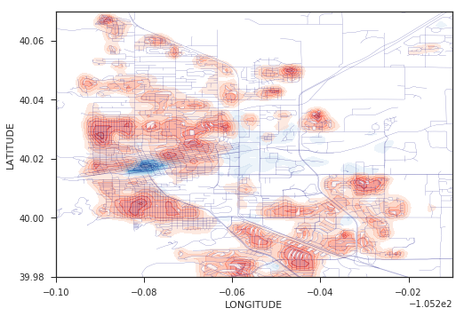

```python
fig, ax = plt.subplots()

sns.kdeplot(nonres_permits.LONGITUDE, nonres_permits.LATITUDE, cmap='Blues', ax=ax, shade=True, shade_lowest=False, bw=.001, alpha=0.5)
sns.kdeplot(res_permits.LONGITUDE, res_permits.LATITUDE, cmap='Reds', ax=ax, shade=True, shade_lowest=False, bw=.001, alpha=0.5)
streets.plot(ax=ax, alpha=0.8, edgecolor='navy', facecolor='white', linewidth=0.2)

plt.xlim([ -105.3, -105.21])
plt.ylim([39.98, 40.07])
```